# The hidden family trees in your blood

How maths recover blood cells’ family history

Dr Jiadong Mao

Lecturer in Statistics, University of Melbourne

17 October 2026

## Who is your closest relative?

[figure not shown]

Your sibling or your cousin?

Closer relatives share a **more recent** ancestor.

People keep names, photos and memories. But what about cells?

Simplified family tree

## Your blood also has a family tree

- White blood cells: fighting invading bacteria and viruses
- Every one of these cells came from another cell
- Just like people, they have a family tree

Which ones are **close relatives**?

## From one cell to a whole family

[figure not shown]

- When cells divide to produce children, they create two copies of everything
- Including DNA – blue maps for making things cells need
- But cells make mistakes when copying

A DNA typo is copied into **every descendant**: a clue to who is related.

## Puzzle: who are the closest relatives?

[figure not shown]

Shared typos reveal relatives — Phylogenetics (i.e. how ‘tribes’ started).

## What do we care about family trees?

[figure not shown]

With age, a few families make a **much bigger share** of the blood. Why?

Simplified illustration based on [Mitchell et al., *Nature* 2022](https://www.nature.com/articles/s41586-022-04786-y)

Growing older

Why does blood change with age?

Recovering

How does blood **rebuild itself** after a blood transplant?

Cancer risk

Which families are **linked** to blood cancer?

Maths and stats turns clues into explanations we can test.

1 in 10 and cancer link: [Jaiswal et al., *New England Journal of Medicine* 2014](https://pubmed.ncbi.nlm.nih.gov/25426837/)

## An evolutionary game

**Rules**

1. Suppose can only maintain 100 blood cells – limited space and resource.
2. When one cell dies, another new one fills in.
3. Different families competing.
4. Cells with a helpful typo (lucky cells) can divide a bit more often – say 10% more often than others.

One cell gets a helpful typo.

Will its family take over? (20 simulations)

[figure not shown]

A small advantage may make you hugely successful family, but not always (that’s life – keep trying!).

## Who to talk to: MIG people

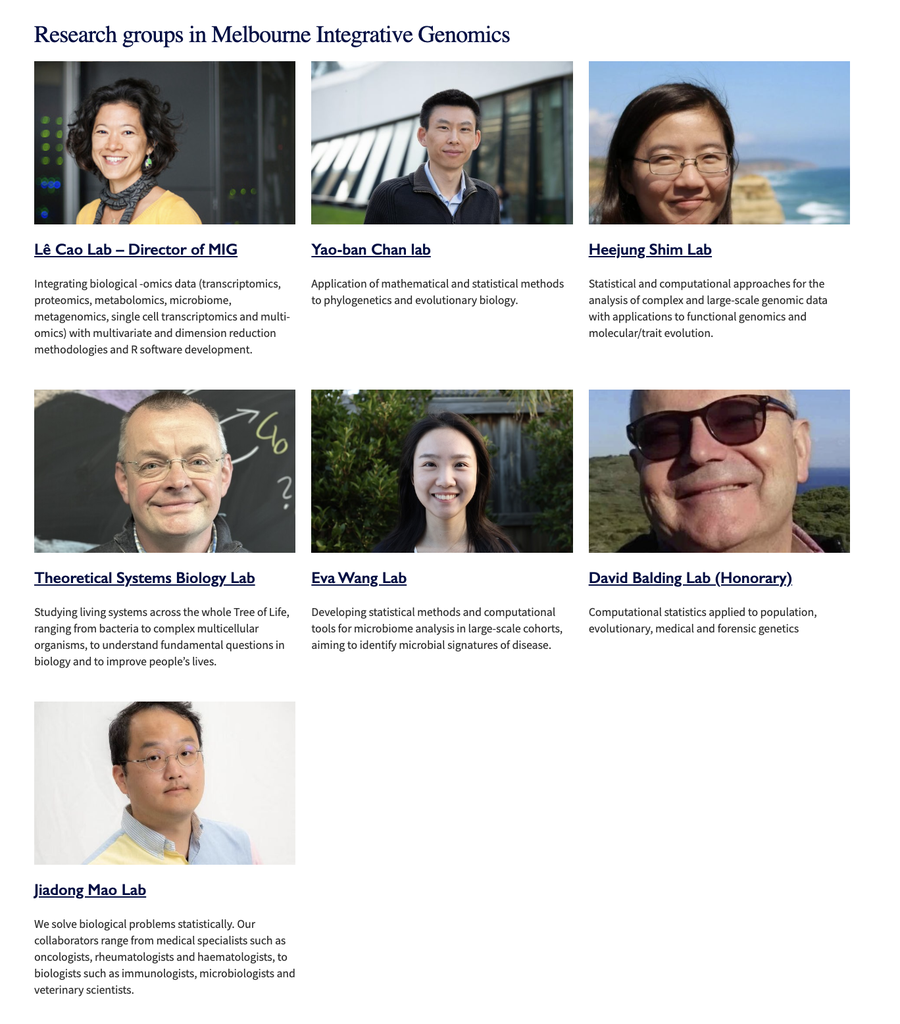

- Melbourne Integrative Genomics (MIG)
- We solve different kinds of maths and stats problems in biology
- We work on big data from biology
- We also work on bacteria (in gut, in soil), forensic statistics (bad guys leave traces too), even quantum computing

Congratulations!

to all of this year’s prize winners

UniMelb Maths Competition 2026 Prize-giving